# STAT 685 - Directed Studies

We next look at leverage values versus standardized deviance residuals.

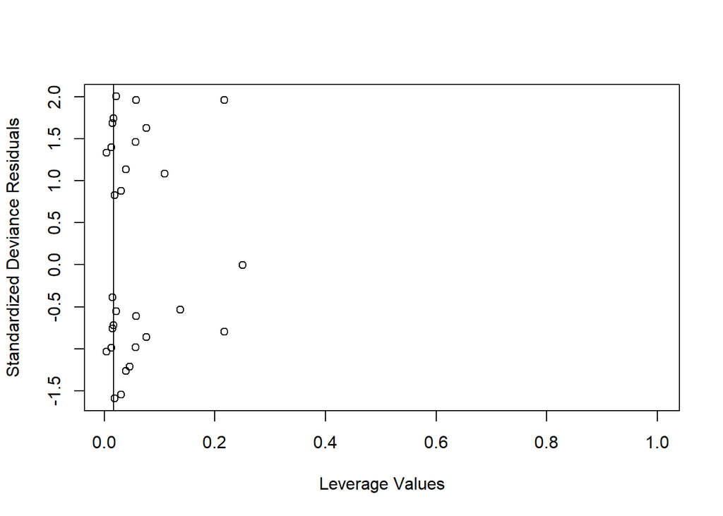

```
## integer(0)
```

```r
hval.glmFit3 <- influence(glmFit3)$hat # hat matrix (leverage values)
p3 <- 3 # number of predictors (PONVhist + Gender + Smoking)
avgLev.glmFit3 <- (p3 + 1) / n  # average leverage
cutLev.glmFit3 <- 2 * avgLev.glmFit3  # cutoff for high leverage
stanresDev.glmFit3 <- residuals(glmFit3)/sqrt(1-hval.glmFit3) # standardized deviance residuals
plot(hval.glmFit3, stanresDev.glmFit3,
     ylab = "Standardized Deviance Residuals",
     xlab = "Leverage Values")
abline(v = cutLev.glmFit3)
identify(hval.glmFit3, stanresDev.glmFit3, labels = Patient)
```

The plot of leverage values and standardized deviance residuals consists of points that are all within two standard deviations, which means there are no bad leverage points.

We next proceed to assess the predictive ability of this model using an ROC curve.

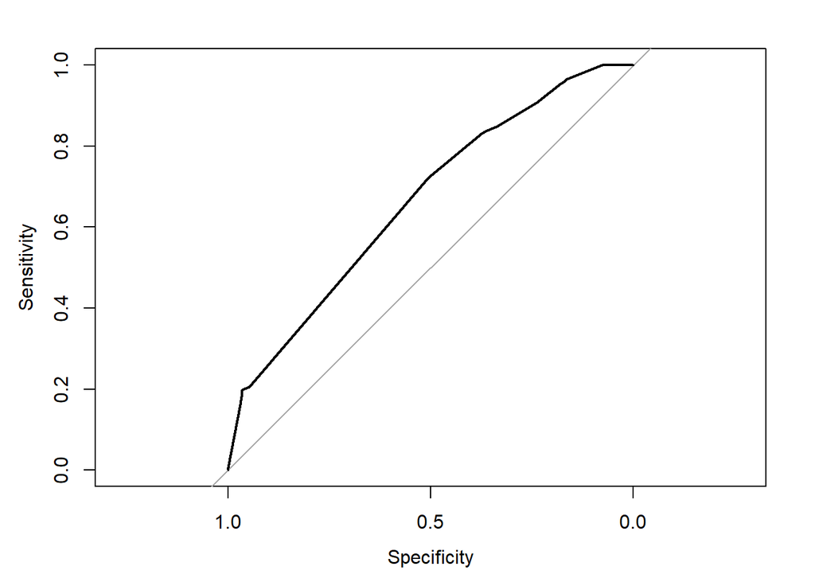

```
##
## Call:
## roc.default(response = PONV0to24, predictor = glmFit3$fitted.values,     plot = TRUE)
##
## Data: glmFit3$fitted.values in 289 controls (PONV0to24 0) < 172 cases (PONV0to24 1).
## Area under the curve: 0.663
```

```r
roc3 <- roc(PONV0to24, glmFit3$fitted.values, plot=TRUE); roc3
```

The area under the ROC curve (AUC) is 0.663. Since the ROC curve is a function of both sensitivity and specificity, the curve is insensitive to class imbalance.

## Resampling techniques

### *k*-fold cross-validation

We next perform logistic regression using five repeats of 10-fold cross-validation, to generate 50 different held-out sets for estimating model accuracy. With *k* chosen to be 10, each training set contains 90% of the entire data set, while each test set contains the other 10% of the data.

```r
set.seed(1)
# Make syntactically valid names for the factor levels of the response variable
# Resampling specification is 5 repetitions of 10-fold cross-validation
logisticReg <- train(make.names(PONV0to24) ~ Age + I(Age^2) + Gender +
                       Diagnosis + Surgery + BMI +
                       Nonsmoker + KinetosisHistory + PONVhistory,
                     data = ponv,
                     method = "glm",
                     metric = "ROC",
                     trControl = trainControl(method = "repeatedcv",
                                              repeats = 5,
                                              classProbs = TRUE))
logisticReg # summary and results
```

```
## Generalized Linear Model
##
## 461 samples
##   8 predictor
##   2 classes: 'X0', 'X1'
##
## No pre-processing
## Resampling: Cross-Validated (10 fold, repeated 5 times)
## Summary of sample sizes: 416, 414, 415, 415, 414, 415, ...
## Resampling results:
##
##   Accuracy   Kappa
##   0.6415667  0.1722848
```

```r
confusionMatrix(logisticReg) # confusion matrix
```

```
## Cross-Validated (10 fold, repeated 5 times) Confusion Matrix
##
## (entries are percentual average cell counts across resamples)
##
##           Reference
## Prediction   X0   X1
##         X0 51.5 24.7
##         X1 11.1 12.6
##
##  Accuracy (average) : 0.6416
```

The choice of *k* to be 10 for *k*-fold cross-validation avoids the high bias of smaller values of *k*, as well as the computational burden of higher values of *k*. *k*-fold cross-validation generally has high variance compared to other methods. The potential issues with bias and variance become negligible for large training sets. Applying 10-fold cross-validation to our data set resulted in training sets each having a sample size between 414 and 416, which may be considered reasonably large. Furthermore, repeating the *k*-fold cross-validation procedure is known as an effective way to increase the precision of the estimates and still maintain a small bias.

```r
summary(logisticReg)
```

```
##
## Call:
## NULL
##
## Deviance Residuals:
##     Min       1Q   Median       3Q      Max
## -1.8339  -0.9581  -0.5420   1.1239   2.3112
##
## Coefficients:
##                     Estimate Std. Error z value Pr(>|z|)
## (Intercept)       -1.994e+01  1.168e+03  -0.017   0.9864
## Age                7.853e-02  5.507e-02   1.426   0.1539
## `I(Age^2)`        -8.170e-04  5.392e-04  -1.515   0.1298
## Gender1            8.152e-01  3.223e-01   2.529   0.0114 *
## Diagnosis1         8.950e-01  6.322e-01   1.416   0.1569
## Diagnosis2         1.077e+00  5.786e-01   1.862   0.0627 .
## Diagnosis3         1.053e+00  7.991e-01   1.318   0.1875
## Diagnosis4         1.189e+00  6.157e-01   1.932   0.0534 .
## Diagnosis5        -1.127e-01  8.928e-01  -0.126   0.8996
## Diagnosis6         1.204e+00  9.253e-01   1.301   0.1933
## Diagnosis7         1.488e+00  1.688e+00   0.882   0.3780
## Diagnosis8        -8.362e-01  1.218e+00  -0.687   0.4924
## Diagnosis9        -8.259e-01  1.453e+00  -0.568   0.5697
## Diagnosis10        2.031e+00  2.040e+00   0.996   0.3193
## Diagnosis11       -1.348e+01  2.400e+03  -0.006   0.9955
## Diagnosis12       -1.376e+01  1.696e+03  -0.008   0.9935
## Diagnosis13       -4.460e-02  8.909e-01  -0.050   0.9601
## Diagnosis14        1.822e+01  1.220e+03   0.015   0.9881
## Diagnosis15        5.787e-01  8.139e-01   0.711   0.4771
## Diagnosis16        9.297e-01  9.279e-01   1.002   0.3164
## Diagnosis17       -1.398e+01  1.336e+03  -0.010   0.9916
## Diagnosis18        1.680e+01  2.400e+03   0.007   0.9944
## Diagnosis19        7.261e-01  9.649e-01   0.753   0.4517
## Diagnosis20        7.744e-01  1.380e+00   0.561   0.5746
## Diagnosis23        1.851e+01  2.400e+03   0.008   0.9938
## Diagnosis24       -1.479e+01  2.400e+03  -0.006   0.9951
## Diagnosis25        1.888e+01  2.400e+03   0.008   0.9937
## Surgery1           1.535e+01  1.168e+03   0.013   0.9895
## Surgery2           1.532e+01  1.168e+03   0.013   0.9895
## Surgery3           3.246e+01  2.669e+03   0.012   0.9903
## Surgery4           1.563e+01  1.168e+03   0.013   0.9893
## Surgery5          -2.504e+00  1.689e+03  -0.001   0.9988
## Surgery7           1.415e+01  1.168e+03   0.012   0.9903
## BMI                1.406e-02  2.485e-02   0.566   0.5716
## Nonsmoker1         5.910e-01  2.495e-01   2.368   0.0179 *
## KinetosisHistory1  1.241e-02  4.976e-01   0.025   0.9801
## PONVhistory1       1.409e+00  3.430e-01   4.106 4.02e-05 ***
## ---
## Signif. codes:  0 '***' 0.001 '**' 0.01 '*' 0.05 '.' 0.1 ' ' 1
##
## (Dispersion parameter for binomial family taken to be 1)
##
##     Null deviance: 609.06  on 460  degrees of freedom
## Residual deviance: 520.59  on 424  degrees of freedom
## AIC: 594.59
##
## Number of Fisher Scoring iterations: 15
```

Three of the predictors in the full model have estimated coefficients that are statistically significant at the $\alpha=.05$ level or lower. In descending order of significance, these are PONV history, gender, and nonsmoker. These match the subset of predictors obtained from the model fitted using all possible subsets on the full data set.

### The bootstrap

```r
bootStrap <- train(make.names(PONV0to24) ~ Age + I(Age^2) + Gender +
                     Diagnosis + Surgery + BMI +
                     Nonsmoker + KinetosisHistory + PONVhistory,
                   data = ponv,
                   method = "glm",
                   metric = "ROC",
                   trControl = trainControl(method = "boot",
                                            classProbs = TRUE))
bootStrap # summary and results
```

```
## Generalized Linear Model
##
## 461 samples
##   8 predictor
##   2 classes: 'X0', 'X1'
##
## No pre-processing
## Resampling: Bootstrapped (25 reps)
## Summary of sample sizes: 461, 461, 461, 461, 461, 461, ...
## Resampling results:
##
##   Accuracy   Kappa
##   0.6293991  0.1629926
```

```r
confusionMatrix(bootStrap) # confusion matrix
```

```
## Bootstrapped (25 reps) Confusion Matrix
##
## (entries are percentual average cell counts across resamples)
##
##           Reference
## Prediction   X0   X1
##         X0 49.2 23.7
##         X1 13.4 13.7
##
##  Accuracy (average) : 0.629
```

```r
summary(bootStrap) # coefficient estimates
```

```
##
## Call:
## NULL
##
## Deviance Residuals:
##     Min       1Q   Median       3Q      Max
## -1.8339  -0.9581  -0.5420   1.1239   2.3112
##
## Coefficients:
##                     Estimate Std. Error z value Pr(>|z|)
## (Intercept)       -1.994e+01  1.168e+03  -0.017   0.9864
## Age                7.853e-02  5.507e-02   1.426   0.1539
## `I(Age^2)`        -8.170e-04  5.392e-04  -1.515   0.1298
## Gender1            8.152e-01  3.223e-01   2.529   0.0114 *
## Diagnosis1         8.950e-01  6.322e-01   1.416   0.1569
## Diagnosis2         1.077e+00  5.786e-01   1.862   0.0627 .
## Diagnosis3         1.053e+00  7.991e-01   1.318   0.1875
## Diagnosis4         1.189e+00  6.157e-01   1.932   0.0534 .
## Diagnosis5        -1.127e-01  8.928e-01  -0.126   0.8996
## Diagnosis6         1.204e+00  9.253e-01   1.301   0.1933
## Diagnosis7         1.488e+00  1.688e+00   0.882   0.3780
## Diagnosis8        -8.362e-01  1.218e+00  -0.687   0.4924
## Diagnosis9        -8.259e-01  1.453e+00  -0.568   0.5697
## Diagnosis10        2.031e+00  2.040e+00   0.996   0.3193
## Diagnosis11       -1.348e+01  2.400e+03  -0.006   0.9955
## Diagnosis12       -1.376e+01  1.696e+03  -0.008   0.9935
## Diagnosis13       -4.460e-02  8.909e-01  -0.050   0.9601
## Diagnosis14        1.822e+01  1.220e+03   0.015   0.9881
## Diagnosis15        5.787e-01  8.139e-01   0.711   0.4771
## Diagnosis16        9.297e-01  9.279e-01   1.002   0.3164
## Diagnosis17       -1.398e+01  1.336e+03  -0.010   0.9916
## Diagnosis18        1.680e+01  2.400e+03   0.007   0.9944
## Diagnosis19        7.261e-01  9.649e-01   0.753   0.4517
## Diagnosis20        7.744e-01  1.380e+00   0.561   0.5746
## Diagnosis23        1.851e+01  2.400e+03   0.008   0.9938
## Diagnosis24       -1.479e+01  2.400e+03  -0.006   0.9951
## Diagnosis25        1.888e+01  2.400e+03   0.008   0.9937
## Surgery1           1.535e+01  1.168e+03   0.013   0.9895
## Surgery2           1.532e+01  1.168e+03   0.013   0.9895
## Surgery3           3.246e+01  2.669e+03   0.012   0.9903
## Surgery4           1.563e+01  1.168e+03   0.013   0.9893
## Surgery5          -2.504e+00  1.689e+03  -0.001   0.9988
## Surgery7           1.415e+01  1.168e+03   0.012   0.9903
## BMI                1.406e-02  2.485e-02   0.566   0.5716
## Nonsmoker1         5.910e-01  2.495e-01   2.368   0.0179 *
## KinetosisHistory1  1.241e-02  4.976e-01   0.025   0.9801
## PONVhistory1       1.409e+00  3.430e-01   4.106 4.02e-05 ***
## ---
## Signif. codes:  0 '***' 0.001 '**' 0.01 '*' 0.05 '.' 0.1 ' ' 1
##
## (Dispersion parameter for binomial family taken to be 1)
##
##     Null deviance: 609.06  on 460  degrees of freedom
## Residual deviance: 520.59  on 424  degrees of freedom
## AIC: 594.59
##
## Number of Fisher Scoring iterations: 15
```

Bootstrapping resulted in a logistic regression model with an accuracy of 63%, which is lower than that obtained from 10-fold cross-validation using 5 repeats.

## References

Apfel, C. C., Kranke, P., Eberhart, L. H. J., Roos, A., and Roewer, N. (2002), “Comparison of Predictive Models for Postoperative Nausea and Vomiting,” *British Journal of Anaesthesia*, 88 (2), 234-40.

Eberhart, L. H. J., Hogel, J., Seeling, W., Staack, A.M., Geldner, G., and Georgieff, M. (2000), “Evaluation of Three Risk Scores to Predict Postoperative Nausea and Vomiting,” *Acta Anaesthesiologica Scandinavica*, 44, 480–488.

James, G., Witten, D., Hastie, T., and Tibshirani, R. (2021), *An Introduction to Statistical Learning* (2nd ed.), New York, NY: Springer Science+Business Media, LLC.

Kuhn, M., and Johnson, K. (2013), *Applied Predictive Modeling*, New York , NY: Springer Science+Business Media, LLC.

Pampel, F. C. (2021), *Logistic Regression* (2nd ed.), Thousand Oaks, CA: SAGE Publications, Inc.

Sheather, S. J. (2009), *A Modern Approach to Regression with R*, New York, NY: Springer Science+Business Media, LLC.

Sinclair, D. R., Chung, F., and Mezei, G. (1999), “Can Postoperative Nausea and Vomiting Be Predicted?” *Anesthesiology*, 91, 109-118.

Thomas, R., Jones, N. A., and Strike, P. (2002), “The Value of Risk Scores for Predicting Postoperative Nausea and Vomiting when Used to Compare Patient Groups in a Randomised Controlled Trial,” *Anaesthesia*, 57, 1119-1128.

van den Bosch, J.E., Kalkman, C. J., Vergouwe, Y., Van Klei, W. A., Bonsel, G. J., Grobbee, D. E., and Moons, K. G. M. (2005), “Assessing the Applicability of Scoring Systems for Predicting Postoperative Nausea and Vomiting,” *Anaesthesia*, 60, 323-331.

Vidakovic, B. (2017), *Engineering Biostatistics*, Hoboken, NJ: John Wiley & Sons Ltd.